# IRIS CLASSIFICATION

- Name : SAGNIK SAMANTA
- Internship ID : UMIP26929
- Internship : Data Analyst Intern at UnifiedMentor
- Project : IRIS Classification

### Project Description

In this Project we are provided with Iris flower Dataset containing three species of flowers (Setosa, Versicolour, and Virginica).Here our main objective is to build a machine learning model that can classify Iris flowers into three categories Setosa, Versicolour and Virginica based on the length and width of their petals and sepals.K-Nearest Neighbor,Decision Tree,Random Forest,Support Vector Machine and Logistic Regression have been employed to train the machine learning model and checked the accuracy of the model using metrices like accuracy score, precision, recall, and F1-score.

### Column Description

Iris flower Dataset contains 150 observations on 5 features.These are listed below

- Sepal Length(cm)
- Sepal Width(cm)
- Petal Length(cm)
- Petal Width(cm)
- Species

## K- Nearest Neighborhood

```python
import numpy as np
import pandas as pd
import matplotlib.pyplot as plt
import seaborn as sns
from sklearn.neighbors import KNeighborsClassifier
from sklearn.preprocessing import StandardScaler
from sklearn.model_selection import train_test_split
from sklearn.metrics import accuracy_score, classification_report, confusion_matrix
```

```python
## import Dataset
df=pd.read_csv("C:/Users/SAGNIK SAMANTA/OneDrive/Desktop/Datasets/Iris.csv")
df.head()
```

|  | SepalLengthCm | SepalWidthCm | PetalLengthCm | PetalWidthCm | Species |
| --- | --- | --- | --- | --- | --- |
| 0 | 5.1 | 3.5 | 1.4 | 0.2 | Iris-setosa |
| 1 | 4.9 | 3.0 | 1.4 | 0.2 | Iris-setosa |
| 2 | 4.7 | 3.2 | 1.3 | 0.2 | Iris-setosa |
| 3 | 4.6 | 3.1 | 1.5 | 0.2 | Iris-setosa |
| 4 | 5.0 | 3.6 | 1.4 | 0.2 | Iris-setosa |

## Data Inspection

```python
## Dimension of the Dataset
print("Shape of the data frame: ",df.shape)
```

```
Shape of the data frame:  (150, 5)
```

```python
## Checking for Missing Values
print("Total null values: ",df.isna().sum().sum())
```

```
Total null values:  0
```

```python
## Checking for Duplicate Values
print("Duplicate values: ",df.duplicated().sum() )
```

```
Duplicate values:  3
```

## Removing the Duplicated Values

```python
df.drop_duplicates(inplace=True)
print("Shape of the data frame: ",df.shape)
print("\n")
print("Species categories with its count \n",df["Species"].value_counts())
```

```
Shape of the data frame:  (147, 5)


Species categories with its count
 Species
Iris-versicolor    50
Iris-virginica     49
Iris-setosa        48
Name: count, dtype: int64
```

```python
df.describe()
```

|  | SepalLengthCm | SepalWidthCm | PetalLengthCm | PetalWidthCm |
| --- | --- | --- | --- | --- |
| count | 147.000000 | 147.000000 | 147.000000 | 147.000000 |
| mean | 5.856463 | 3.055782 | 3.780272 | 1.208844 |
| std | 0.829100 | 0.437009 | 1.759111 | 0.757874 |
| min | 4.300000 | 2.000000 | 1.000000 | 0.100000 |
| 25% | 5.100000 | 2.800000 | 1.600000 | 0.300000 |
| 50% | 5.800000 | 3.000000 | 4.400000 | 1.300000 |
| 75% | 6.400000 | 3.300000 | 5.100000 | 1.800000 |
| max | 7.900000 | 4.400000 | 6.900000 | 2.500000 |

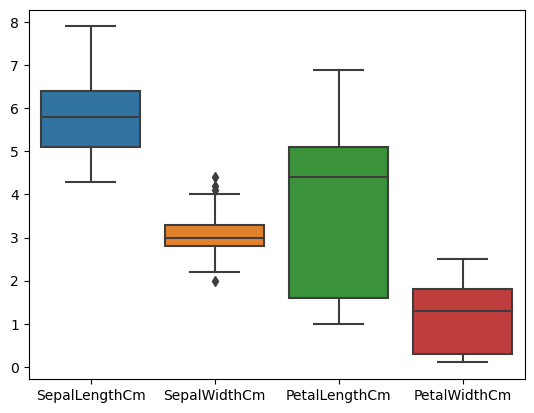

```python
## Boxplot
sns.boxplot(df)
```

```python
df.columns
```

```
Index(['SepalLengthCm', 'SepalWidthCm', 'PetalLengthCm', 'PetalWidthCm',
       'Species'],
      dtype='object')
```

```python
## Separate the independent and dependent variables using the slicing method.
X=df.drop("Species",axis=1)
y=df[['Species']]
```

```python
## Split the data into training and testing sets.
X_train,X_test,y_train,y_test=train_test_split(X,y,test_size=0.2,random_state=100)
```

```python
## Scale the data using StandardScaler
scaler = StandardScaler()
X_train_scaled = scaler.fit_transform(X_train)
X_test_scaled = scaler.transform(X_test)
```

```python
## Reshape y to a 1D array
y_train = np.ravel(y_train)
y_test = np.ravel(y_test)
```

```python
knn=KNeighborsClassifier(n_neighbors=5)
knn.fit(X_train_scaled,y_train)
```

```
KNeighborsClassifier()
```

```python
## Calculate the Accuracy of the model
Prediction=knn.predict(X_test_scaled)
print('The accuracy of the KNN is',accuracy_score(Prediction,y_test))
print("Classification Report:")
print(classification_report(y_test, Prediction))
print("Confusion Matrix:")
print(confusion_matrix(y_test, Prediction))
```

```
The accuracy of the KNN is 0.9
Classification Report:
                 precision    recall  f1-score   support

    Iris-setosa       1.00      1.00      1.00         9
Iris-versicolor       0.70      1.00      0.82         7
 Iris-virginica       1.00      0.79      0.88        14

       accuracy                           0.90        30
      macro avg       0.90      0.93      0.90        30
   weighted avg       0.93      0.90      0.90        30

Confusion Matrix:
[[ 9  0  0]
 [ 0  7  0]
 [ 0  3 11]]
```

### Conclusion :

- Precision : Out of all the flower species that the model predicted would get classified into three categories,the model perdicted the outcomes as 100% as Setosa,70% for Versicolor and 100% for Virginica
- Recall : Out of all the flower species that actually got classified into three categories,the model perdicted the outcomes correctly as 100% as Setosa,100% for Versicolor and 79% for Virginica
- F1-Score : This value is calculated as = 2 *(Precision* Recall) / (Precision + Recall)
  - Since the value is close to 1 , therefore we can state that our model correctly classified flowers into three flower species
- Support : These values simply tell us how many flowers belonged to each class in the test dataset.We can see that among the flowers in the test dataset, 9 flowers belong to Setosa, 14 flowers belongs to verginica and 7 flowers belong to versicolor.

## Decision Tree Classifier

```python
import numpy as np
import pandas as pd
from sklearn.model_selection import train_test_split
from sklearn.tree import DecisionTreeClassifier
from sklearn.metrics import accuracy_score, classification_report, confusion_matrix
from sklearn import tree
import matplotlib.pyplot as plt
```

```python
## import Dataset
df=pd.read_csv("C:/Users/SAGNIK SAMANTA/OneDrive/Desktop/Datasets/Iris.csv")
df.head()
```

|  | SepalLengthCm | SepalWidthCm | PetalLengthCm | PetalWidthCm | Species |
| --- | --- | --- | --- | --- | --- |
| 0 | 5.1 | 3.5 | 1.4 | 0.2 | Iris-setosa |
| 1 | 4.9 | 3.0 | 1.4 | 0.2 | Iris-setosa |
| 2 | 4.7 | 3.2 | 1.3 | 0.2 | Iris-setosa |
| 3 | 4.6 | 3.1 | 1.5 | 0.2 | Iris-setosa |
| 4 | 5.0 | 3.6 | 1.4 | 0.2 | Iris-setosa |

```python
df.columns
```

```
Index(['SepalLengthCm', 'SepalWidthCm', 'PetalLengthCm', 'PetalWidthCm',
       'Species'],
      dtype='object')
```

```python
## Separate the independent and dependent variables using the slicing method.
X=df.drop("Species",axis=1)
y=df[['Species']]
```

```python
## Split the data into training and testing sets.
X_train,X_test,y_train,y_test=train_test_split(X,y,test_size=0.2,random_state=100)
```

```python
## Train the model using the decision tree classifier.
clf_gini=DecisionTreeClassifier(criterion="gini",random_state=100,max_depth=3,min_samples_leaf=5)
clf_gini.fit(X_train,y_train)
```

```
DecisionTreeClassifier(max_depth=3, min_samples_leaf=5, random_state=100)
```

```python
y_Predict_gini=clf_gini.predict(X_test)
y_Predict_gini
```

```
array(['Iris-virginica', 'Iris-setosa', 'Iris-virginica', 'Iris-setosa',
       'Iris-virginica', 'Iris-virginica', 'Iris-setosa', 'Iris-setosa',
       'Iris-virginica', 'Iris-setosa', 'Iris-setosa', 'Iris-virginica',
       'Iris-setosa', 'Iris-setosa', 'Iris-virginica', 'Iris-versicolor',
       'Iris-versicolor', 'Iris-virginica', 'Iris-virginica',
       'Iris-virginica', 'Iris-virginica', 'Iris-setosa',
       'Iris-virginica', 'Iris-setosa', 'Iris-versicolor',
       'Iris-virginica', 'Iris-versicolor', 'Iris-setosa',
       'Iris-versicolor', 'Iris-virginica'], dtype=object)
```

```python
## Calculate the accuracy of the model using the accuracy score function.
print(("Accuracy is"),accuracy_score(y_test,y_Predict_gini)*100)
print("Classification Report:")
print(classification_report(y_test, y_Predict_gini))
print("Confusion Matrix:")
print(confusion_matrix(y_test, y_Predict_gini))
```

```
Accuracy is 96.66666666666667
Classification Report:
                 precision    recall  f1-score   support

    Iris-setosa       1.00      1.00      1.00        11
Iris-versicolor       1.00      0.83      0.91         6
 Iris-virginica       0.93      1.00      0.96        13

       accuracy                           0.97        30
      macro avg       0.98      0.94      0.96        30
   weighted avg       0.97      0.97      0.97        30

Confusion Matrix:
[[11  0  0]
 [ 0  5  1]
 [ 0  0 13]]
```

Our prediction model shows that there is an excellent accuracy score of 96.66666666666667 percent.

- Precision : Out of all the flower species that the model predicted would get classified into three categories,the model perdicted the outcomes as 100% as Setosa,100% for Versicolor and 93% for Virginica
- Recall : Out of all the flower species that actually got classified into three categories,the model perdicted the outcomes correctly as 100% as Setosa,83% for Versicolor and 100% for Virginica
- F1-Score : This value is calculated as = 2 *(Precision* Recall) / (Precision + Recall)
  - Since the value is very close to 1 , therefore we can state that our model correctly classified flowers into three flower species
- Support : These values simply tell us how many flowers belonged to each class in the test dataset.We can see that among the flowers in the test dataset, 11 flowers belong to Setosa, 13 flowers belongs to verginica and 6 flowers belong to versicolor.

[output not shown]

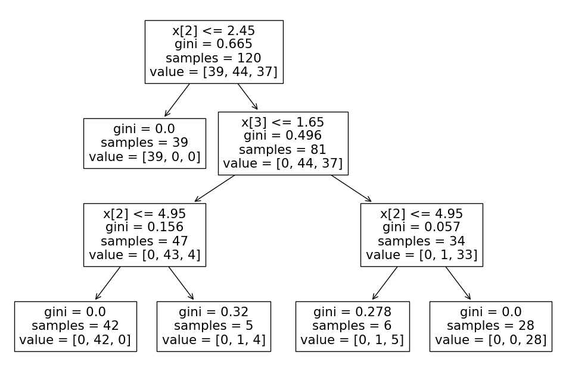

```python
plt.figure(figsize=(12,8))
tree.plot_tree(clf_gini.fit(X_train, y_train))
```

```python
## Entropy Method
## Train the model using the decision tree classifier.
clf_en=DecisionTreeClassifier(criterion="entropy",random_state=100,max_depth=3,min_samples_leaf=5)
clf_en.fit(X_train,y_train)
```

```
DecisionTreeClassifier(criterion='entropy', max_depth=3, min_samples_leaf=5,
                       random_state=100)
```

```python
y_Predict_en=clf_en.predict(X_test)
y_Predict_en
```

```
array(['Iris-virginica', 'Iris-setosa', 'Iris-virginica', 'Iris-setosa',
       'Iris-virginica', 'Iris-virginica', 'Iris-setosa', 'Iris-setosa',
       'Iris-virginica', 'Iris-setosa', 'Iris-setosa', 'Iris-virginica',
       'Iris-setosa', 'Iris-setosa', 'Iris-virginica', 'Iris-versicolor',
       'Iris-versicolor', 'Iris-virginica', 'Iris-virginica',
       'Iris-virginica', 'Iris-virginica', 'Iris-setosa',
       'Iris-virginica', 'Iris-setosa', 'Iris-versicolor',
       'Iris-virginica', 'Iris-versicolor', 'Iris-setosa',
       'Iris-versicolor', 'Iris-virginica'], dtype=object)
```

```python
## Calculate the accuracy of the model using the accuracy score function.
print(("Accuracy is"),accuracy_score(y_test,y_Predict_en)*100)
print("Classification Report:")
print(classification_report(y_test, y_Predict_en))
print("Confusion Matrix:")
print(confusion_matrix(y_test, y_Predict_en))
```

```
Accuracy is 96.66666666666667
Classification Report:
                 precision    recall  f1-score   support

    Iris-setosa       1.00      1.00      1.00        11
Iris-versicolor       1.00      0.83      0.91         6
 Iris-virginica       0.93      1.00      0.96        13

       accuracy                           0.97        30
      macro avg       0.98      0.94      0.96        30
   weighted avg       0.97      0.97      0.97        30

Confusion Matrix:
[[11  0  0]
 [ 0  5  1]
 [ 0  0 13]]
```

Our prediction model shows that there is an excellent accuracy score of 96.66666666666667 percent.

- Precision : Out of all the flower species that the model predicted would get classified into three categories,the model perdicted the outcomes as 100% as Setosa,100% for Versicolor and 93% for Virginica
- Recall : Out of all the flower species that actually got classified into three categories,the model perdicted the outcomes correctly as 100% as Setosa,83% for Versicolor and 100% for Virginica
- F1-Score : This value is calculated as = 2 *(Precision* Recall) / (Precision + Recall)
  - Since the value is very close to 1 , therefore we can state that our model correctly classified flowers into three flower species
- Support : These values simply tell us how many flowers belonged to each class in the test dataset.We can see that among the flowers in the test dataset, 11 flowers belong to Setosa, 13 flowers belongs to verginica and 6 flowers belong to versicolor.

### Visualize decision-trees

[output not shown]

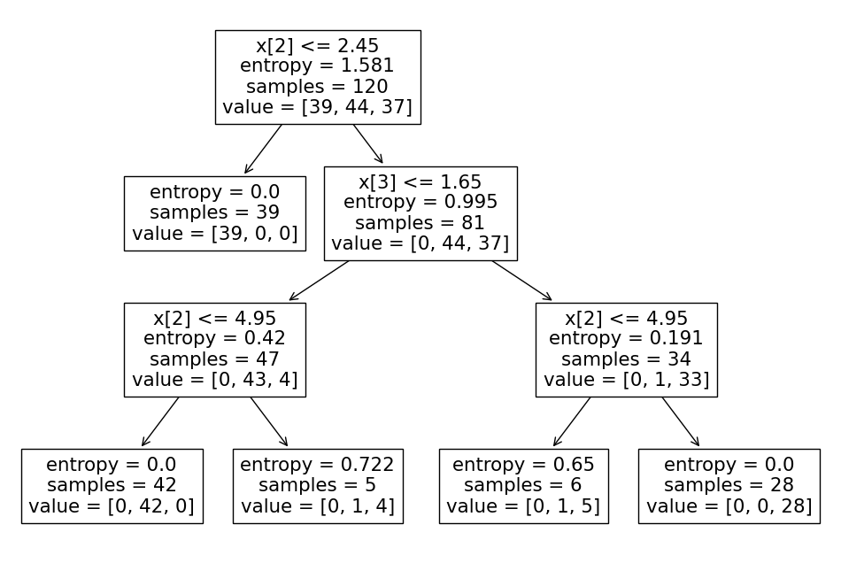

```python
plt.figure(figsize=(12,8))
tree.plot_tree(clf_en.fit(X_train, y_train))
```

```python
## Calculate the training set Accuracy
y_pred_train_en = clf_en.predict(X_train)
y_pred_train_en
```

[output not shown]

```python
print('Training-set accuracy score: {0:0.4f}'. format(accuracy_score(y_train, y_pred_train_en)))
```

```
Training-set accuracy score: 0.9833
```

```python
## Check for Overfitting and Underfitting
## print the scores on training and test set

print('Training set score: {:.4f}'.format(clf_en.score(X_train, y_train)))

print('Test set score: {:.4f}'.format(clf_en.score(X_test, y_test)))
```

```
Training set score: 0.9833
Test set score: 0.9667
```

#### We can see that the training-set score and test-set score is same as above. The training-set accuracy score is 0.0.9833 while the test-set accuracy to be 0.9667. These two values are quite comparable. So, there is no sign of overfitting.

## Random Forest Classifier

```python
from sklearn.ensemble import RandomForestClassifier
from sklearn.model_selection import train_test_split
from sklearn.metrics import accuracy_score, classification_report, confusion_matrix
```

```python
## import Dataset
df=pd.read_csv("C:/Users/SAGNIK SAMANTA/OneDrive/Desktop/Datasets/Iris.csv")
df.head()
```

|  | SepalLengthCm | SepalWidthCm | PetalLengthCm | PetalWidthCm | Species |
| --- | --- | --- | --- | --- | --- |
| 0 | 5.1 | 3.5 | 1.4 | 0.2 | Iris-setosa |
| 1 | 4.9 | 3.0 | 1.4 | 0.2 | Iris-setosa |
| 2 | 4.7 | 3.2 | 1.3 | 0.2 | Iris-setosa |
| 3 | 4.6 | 3.1 | 1.5 | 0.2 | Iris-setosa |
| 4 | 5.0 | 3.6 | 1.4 | 0.2 | Iris-setosa |

```python
df.columns
```

```
Index(['SepalLengthCm', 'SepalWidthCm', 'PetalLengthCm', 'PetalWidthCm',
       'Species'],
      dtype='object')
```

```python
## Separate the independent and dependent variables using the slicing method.
X=df.drop("Species",axis=1)
y=df[['Species']]
```

```python
## Split the data into training and testing sets.
X_train,X_test,y_train,y_test=train_test_split(X,y,test_size=0.2,random_state=100)
```

```python
## Build a Random Forest Classifier Model
forest=RandomForestClassifier(n_estimators=10,criterion="entropy",random_state=0)
forest.fit(X_train,y_train)
```

[output not shown]

```
RandomForestClassifier(criterion='entropy', n_estimators=10, random_state=0)
```

```python
## Calculate the accuracy of the model
Prediction=forest.predict(X_test)
print('The accuracy of the Random Forest is',accuracy_score(Prediction,y_test))
print("Classification Report:")
print(classification_report(y_test, Prediction))
print("Confusion Matrix:")
print(confusion_matrix(y_test, Prediction))
```

```
The accuracy of the Random Forest is 0.9666666666666667
Classification Report:
                 precision    recall  f1-score   support

    Iris-setosa       1.00      1.00      1.00        11
Iris-versicolor       1.00      0.83      0.91         6
 Iris-virginica       0.93      1.00      0.96        13

       accuracy                           0.97        30
      macro avg       0.98      0.94      0.96        30
   weighted avg       0.97      0.97      0.97        30

Confusion Matrix:
[[11  0  0]
 [ 0  5  1]
 [ 0  0 13]]
```

### Conclusion :

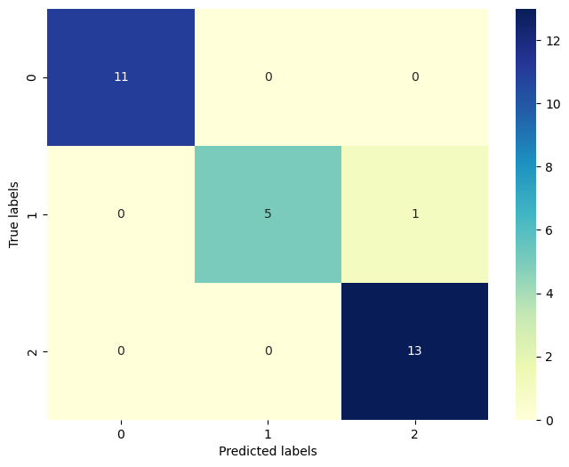

```python
# Plot the confusion matrix
plt.figure(figsize=(8, 6))
sns.heatmap(confusion_matrix(y_test, Prediction), annot=True, cmap="YlGnBu")
plt.xlabel("Predicted labels")
plt.ylabel("True labels")
plt.show()
```

Our prediction model shows that there is an excellent accuracy score of 96.66666666666667 percent.

- Precision : Out of all the flower species that the model predicted would get classified into three categories,the model perdicted the outcomes as 100% as Setosa,100% for Versicolor and 93% for Virginica
- Recall : Out of all the flower species that actually got classified into three categories,the model perdicted the outcomes correctly as 100% as Setosa,83% for Versicolor and 100% for Virginica
- F1-Score : This value is calculated as = 2 *(Precision* Recall) / (Precision + Recall)
  - Since the value is very close to 1 , therefore we can state that our model correctly classified flowers into three flower species
- Support : These values simply tell us how many flowers belonged to each class in the test dataset.We can see that among the flowers in the test dataset, 11 flowers belong to Setosa, 13 flowers belongs to verginica and 6 flowers belong to versicolor.

## Support Vector Machine

```python
from sklearn.svm import SVC
from sklearn.model_selection import train_test_split
from sklearn.metrics import accuracy_score, classification_report, confusion_matrix
```

```python
## import Dataset
df=pd.read_csv("C:/Users/SAGNIK SAMANTA/OneDrive/Desktop/Datasets/Iris.csv")
df.head()
```

|  | SepalLengthCm | SepalWidthCm | PetalLengthCm | PetalWidthCm | Species |
| --- | --- | --- | --- | --- | --- |
| 0 | 5.1 | 3.5 | 1.4 | 0.2 | Iris-setosa |
| 1 | 4.9 | 3.0 | 1.4 | 0.2 | Iris-setosa |
| 2 | 4.7 | 3.2 | 1.3 | 0.2 | Iris-setosa |
| 3 | 4.6 | 3.1 | 1.5 | 0.2 | Iris-setosa |
| 4 | 5.0 | 3.6 | 1.4 | 0.2 | Iris-setosa |

```python
df.columns
```

```
Index(['SepalLengthCm', 'SepalWidthCm', 'PetalLengthCm', 'PetalWidthCm',
       'Species'],
      dtype='object')
```

```python
## Separate the independent and dependent variables using the slicing method.
X=df.drop("Species",axis=1)
y=df[['Species']]
```

```python
## Split the data into training and testing sets.
X_train,X_test,y_train,y_test=train_test_split(X,y,test_size=0.2,random_state=100)
```

```python
y_train=np.ravel(y_train)
y_test=np.ravel(y_test)
```

```python
## Model Building
svc=SVC()
svc.fit(X_train,y_train)
```

```
SVC()
```

```python
## Checking the accuracy of the Model
Prediction=svc.predict(X_test)
print('The accuracy of the SVC is',accuracy_score(Prediction,y_test))
print("Classification Report:")
print(classification_report(y_test, Prediction))
print("Confusion Matrix:")
print(confusion_matrix(y_test, Prediction))
```

```
The accuracy of the SVC is 1.0
Classification Report:
                 precision    recall  f1-score   support

    Iris-setosa       1.00      1.00      1.00        11
Iris-versicolor       1.00      1.00      1.00         6
 Iris-virginica       1.00      1.00      1.00        13

       accuracy                           1.00        30
      macro avg       1.00      1.00      1.00        30
   weighted avg       1.00      1.00      1.00        30

Confusion Matrix:
[[11  0  0]
 [ 0  6  0]
 [ 0  0 13]]
```

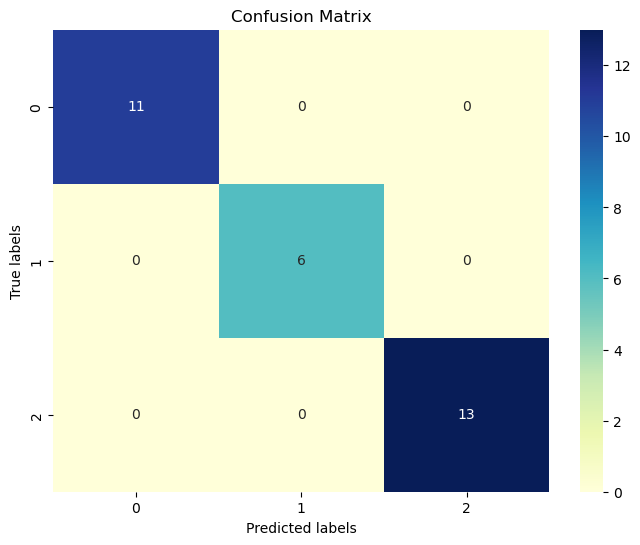

```python
# Plot the confusion matrix
plt.figure(figsize=(8, 6))
sns.heatmap(confusion_matrix(y_test, Prediction), annot=True, cmap="YlGnBu")
plt.xlabel("Predicted labels")
plt.ylabel("True labels")
plt.title("Confusion Matrix")
plt.show()
```

### Conclusion :

Our prediction model shows that there is an excellent accuracy score of 100 percent.

- Precision : Out of all the flower species that the model predicted would get classified into three categories,the model perdicted the outcomes as 100% as Setosa,100% for Versicolor and 100% for Virginica
- Recall : Out of all the flower species that actually got classified into three categories,the model perdicted the outcomes correctly as 100% as Setosa,100% for Versicolor and 100% for Virginica
- F1-Score : This value is calculated as = 2 *(Precision* Recall) / (Precision + Recall)
  - Since the value is 1 , therefore we can state that our model correctly classified flowers into three flower species
- Support : These values simply tell us how many flowers belonged to each class in the test dataset.We can see that among the flowers in the test dataset, 11 flowers belong to Setosa, 13 flowers belongs to verginica and 6 flowers belong to versicolor.

## Logistic Regression

```python
from sklearn.linear_model import LogisticRegression
from sklearn.model_selection import train_test_split
from sklearn.metrics import accuracy_score,confusion_matrix,classification_report
```

```python
## import Dataset
df=pd.read_csv("C:/Users/SAGNIK SAMANTA/OneDrive/Desktop/Datasets/Iris.csv")
df.head()
```

|  | SepalLengthCm | SepalWidthCm | PetalLengthCm | PetalWidthCm | Species |
| --- | --- | --- | --- | --- | --- |
| 0 | 5.1 | 3.5 | 1.4 | 0.2 | Iris-setosa |
| 1 | 4.9 | 3.0 | 1.4 | 0.2 | Iris-setosa |
| 2 | 4.7 | 3.2 | 1.3 | 0.2 | Iris-setosa |
| 3 | 4.6 | 3.1 | 1.5 | 0.2 | Iris-setosa |
| 4 | 5.0 | 3.6 | 1.4 | 0.2 | Iris-setosa |

## Data Inspection

```python
## Dimension of the Dataset
print("Shape of the data frame: ",df.shape)
```

```
Shape of the data frame:  (150, 5)
```

```python
## Checking for Missing Values
print("Total null values: ",df.isna().sum().sum())
```

```
Total null values:  0
```

```python
## Checking for Duplicate Values
print("Duplicate values: ",df.duplicated().sum() )
```

```
Duplicate values:  3
```

## Removing the Duplicated Values

```python
df.drop_duplicates(inplace=True)
print("Shape of the data frame: ",df.shape)
print("\n")
print("Species categories with its count \n",df["Species"].value_counts())
```

```
Shape of the data frame:  (147, 5)


Species categories with its count
 Species
Iris-versicolor    50
Iris-virginica     49
Iris-setosa        48
Name: count, dtype: int64
```

```python
df.describe()
```

|  | SepalLengthCm | SepalWidthCm | PetalLengthCm | PetalWidthCm |
| --- | --- | --- | --- | --- |
| count | 147.000000 | 147.000000 | 147.000000 | 147.000000 |
| mean | 5.856463 | 3.055782 | 3.780272 | 1.208844 |
| std | 0.829100 | 0.437009 | 1.759111 | 0.757874 |
| min | 4.300000 | 2.000000 | 1.000000 | 0.100000 |
| 25% | 5.100000 | 2.800000 | 1.600000 | 0.300000 |
| 50% | 5.800000 | 3.000000 | 4.400000 | 1.300000 |
| 75% | 6.400000 | 3.300000 | 5.100000 | 1.800000 |
| max | 7.900000 | 4.400000 | 6.900000 | 2.500000 |

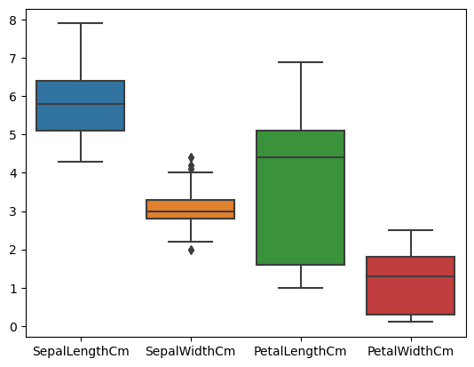

```python
## Boxplot
sns.boxplot(data=df)
```

from the above box plot it's clear

- sepal_width has outliers and it's right skewed
- petal_length and petal_with are negatively skewed
- sepal_length is symmetrical

```python
df.columns
```

```
Index(['SepalLengthCm', 'SepalWidthCm', 'PetalLengthCm', 'PetalWidthCm',
       'Species'],
      dtype='object')
```

```python
from sklearn.preprocessing import LabelEncoder
label_encoder=LabelEncoder()
df["Species"]=label_encoder.fit_transform(df["Species"])
print(df.head(10))
print("\n")
print(df["Species"].value_counts())
```

```
   SepalLengthCm  SepalWidthCm  PetalLengthCm  PetalWidthCm  Species
0            5.1           3.5            1.4           0.2        0
1            4.9           3.0            1.4           0.2        0
2            4.7           3.2            1.3           0.2        0
3            4.6           3.1            1.5           0.2        0
4            5.0           3.6            1.4           0.2        0
5            5.4           3.9            1.7           0.4        0
6            4.6           3.4            1.4           0.3        0
7            5.0           3.4            1.5           0.2        0
8            4.4           2.9            1.4           0.2        0
9            4.9           3.1            1.5           0.1        0


Species
1    50
2    49
0    48
Name: count, dtype: int64
```

```python
## Separate the independent and dependent variables using the slicing method.
X=df.drop("Species",axis=1)
y=df[['Species']]
```

```python
## Split the data into training and testing sets.
X_train,X_test,y_train,y_test=train_test_split(X,y,test_size=0.2,random_state=100)
```

```python
## Model Building
log_reg = LogisticRegression()
log_reg.fit(X_train,y_train)
```

[output not shown]

```
LogisticRegression()
```

```python
## Checking the accuracy of the Model
Prediction=log_reg.predict(X_test)
print('The accuracy of the Logistic Regression is',accuracy_score(Prediction,y_test))
```

```
The accuracy of the Logistic Regression is 0.9666666666666667
```

```python
## Confusion Matrix
cm=confusion_matrix(y_test, Prediction)
print("Confusion Matrix:\n ",cm)
print('\nTrue Positives(TP) = ', cm[0,0])

print('\nTrue Negatives(TN) = ', cm[1,1])

print('\nFalse Positives(FP) = ', cm[0,1])

print('\nFalse Negatives(FN) = ', cm[1,0])
```

```
Confusion Matrix:
  [[ 9  0  0]
 [ 0  7  0]
 [ 0  1 13]]

True Positives(TP) =  9

True Negatives(TN) =  7

False Positives(FP) =  0

False Negatives(FN) =  0
```

```python
## Classification Report
print("Classification Report:")
print(classification_report(y_test, Prediction))
print("Confusion Matrix:")
print(confusion_matrix(y_test, Prediction))
```

```
Classification Report:
              precision    recall  f1-score   support

           0       1.00      1.00      1.00         9
           1       0.88      1.00      0.93         7
           2       1.00      0.93      0.96        14

    accuracy                           0.97        30
   macro avg       0.96      0.98      0.97        30
weighted avg       0.97      0.97      0.97        30

Confusion Matrix:
[[ 9  0  0]
 [ 0  7  0]
 [ 0  1 13]]
```

### Conclusion :

- Precision : Out of all the flower species that the model predicted would get classified into three categories,the model perdicted the outcomes as 100% as Setosa,88% for Versicolor and 100% for Virginica
- Recall : Out of all the flower species that actually got classified into three categories,the model perdicted the outcomes correctly as 100% as Setosa,100% for Versicolor and 93% for Virginica
- F1-Score : This value is calculated as = 2 *(Precision* Recall) / (Precision + Recall)
  - Since the value is very close to 1 , therefore we can state that our model correctly classified flowers into three flower species
- Support : These values simply tell us how many flowers belonged to each class in the test dataset.We can see that among the flowers in the test dataset, 9 flowers belong to Setosa, 14 flowers belongs to verginica and 7 flowers belong to versicolor.